# Assignment 2

Samantha Stephens, Methlha Ganelang, Nathan Colvin, Stephen Bottrell

25 March 2018

## TIDYING THE DATA

```r
survey = read.csv('http://dmac.netlify.com/assignments/data/survey.csv',
                   na = c("n/a", "NA")) %>%
  filter(id != 64)
survey <- survey %>%
## Replaced A, B, C, D, E which 1, 2, 3, 4 and other respestively
  mutate(Q1 = sub("A", "1", Q1)) %>%
  mutate(Q1 = sub("B", "2", Q1)) %>%
  mutate(Q1 = sub("C", "3", Q1)) %>%
  mutate(Q1 = sub("D", "4", Q1)) %>%
  mutate(Q1 = sub("E", "Other", Q1)) %>%
## Removed hrs, changed all values to integars, removed hours
  mutate(Q2 = sub("1/2", "0.5", Q2)) %>%
  mutate(Q2 = sub("three times", "3.00", Q2)) %>%
  mutate(Q2 = sub("hrs", "", Q2)) %>%
  mutate(Q2 = sub(" hours", "", Q2)) %>%
  mutate(Q2 = sub("\n", "", Q2)) %>%
  mutate(Q2 = sub("HOUR", "", Q2)) %>%
  mutate(Q2 = sub("4/7", "0.57", Q2)) %>%
## mutated the words so all hip hops were the same.
  mutate(Q4 = tolower(Q4)) %>%
  mutate(Q4 = sub("hip-pop", "hip hop", Q4)) %>%
  mutate(Q4 = sub("k-pop", "k pop", Q4)) %>%
  mutate(Q4 = sub("rnb", "r&b", Q4)) %>%
  mutate(Q4 = sub("popular", "pop", Q4)) %>%
  mutate(Q4 = sub("country music", "country", Q4)) %>%
  mutate(Q4 = sub("alt rock", "alternative rock", Q4)) %>%
  mutate(Q4 = sub("hip-hop", "hip hop", Q4)) %>%
  mutate(Q4 = sub("pop music", "pop", Q4)) %>%
  mutate(Q4 = sub("music", NA, Q4)) %>%
  mutate(Q4 = sub("rock and/or roll", "rock", Q4)) %>%
  mutate(Q4 = sub("hiphop", "hip hop", Q4)) %>%
  mutate(Q4 = sub("lo-fi", "lo fi", Q4)) %>%
  mutate(Q4 = sub("-", NA, Q4)) %>%
  ## deleted any non-numeric characters present in the data
  mutate(Q5 = sub("hrs", "", Q5)) %>%
  mutate(Q5 = sub(" Hours", "", Q5)) %>%
  mutate(Q5 = sub(" hours", "", Q5)) %>%
  mutate(Q5 = sub("Choosing not to answer", NA, Q5)) %>%
  mutate(Q5 = sub("-", NA, Q5)) %>%
  mutate(Q5 = sub("HOUR", "", Q5)) %>%
  ## converted to all lowercase and ensured there were no duplicates
  mutate(Q6 = tolower(Q6)) %>%
  mutate(Q6 = sub("flying", "flight", Q6)) %>%
  mutate(Q6 = sub("teleporting", "teleportation", Q6)) %>%
  mutate(Q6 = sub("go back to a past time", "time travel", Q6)) %>%
  mutate(Q6 = sub("predict the future", "forecasting", Q6)) %>%
  mutate(Q6 = sub("fly", "flight", Q6)) %>%
  mutate(Q6 = sub("invisibility", "invisible", Q6)) %>%
  mutate(Q6 = sub("time control", "control time", Q6)) %>%
  mutate(Q6 = sub("to never have to sleep", "not needing sleep", Q6)) %>%
  mutate(Q6 = sub("forecast the future", "forecasting", Q6)) %>%
  mutate(Q6 = sub("time-reverse", "control time", Q6)) %>%
  mutate(Q6 = sub("freeze time", "control time", Q6)) %>%
  mutate(Q6 = sub("can go to wherever i want in any time", "time travel", Q6)) %>%
  mutate(Q6 = sub("freeze time", "control time", Q6)) %>%
  mutate(Q6 = sub("imortality", "immortality", Q6)) %>%
  ## changed to more relevant names reflecting the data
  mutate(Q7 = sub("A", "two sizes too big", Q7)) %>%
  mutate(Q7 = sub("B", "one size too small", Q7)) %>%
  mutate(Q7 = sub("C", "neither", Q7)) %>%
  ## changed to more relevant names reflecting the data
  mutate(Q8 = sub("A", "0 - (<3)", Q8)) %>%
  mutate(Q8 = sub("B", "3 - (<6)", Q8)) %>%
  mutate(Q8 = sub("C", "6 - (<9)", Q8)) %>%
  mutate(Q8 = sub("D", "9 - (<12)", Q8)) %>%
  mutate(Q8 = sub("E", "above or = 12", Q8)) %>%
 ## Question Q9 changed words including Captial letters to group into thier sections
  mutate(Q9 = sub('n/a',NA, Q9)) %>%
  mutate(Q9 = sub('netlfix', 'Netflix',Q9)) %>%
  mutate(Q9 = sub('netflix','Netflix', Q9)) %>%
  mutate(Q9 = sub("No television", "None", Q9)) %>%
  mutate(Q9 = sub("I do not watch television.","None", Q9)) %>%
  mutate(Q9 = sub("I don't watch television","None", Q9)) %>%
  mutate(Q9 = sub('Nothing',"None", Q9))  %>%
  mutate(Q9 = sub("dont watch tv", "None", Q9)) %>%
  mutate(Q9 = sub("dont watch","None", Q9)) %>%
  mutate(Q9 = sub("Don't watch television","None", Q9)) %>%
  mutate(Q9 = sub("i don't watch tv","None", Q9)) %>%
  mutate(Q9 = sub("I don't","None", Q9)) %>%
  mutate(Q9 = sub('none',"None", Q9))  %>%
  mutate(Q9 = sub('non',"None", Q9))  %>%
  mutate(Q9 = sub('no idea', NA, Q9))%>%
  mutate(Q9 = sub("NA",NA, Q9)) %>%
  mutate(Q9 = sub("Foxtel...",'Foxtel', Q9)) %>%
  mutate(Q9 = sub('stan', 'Stan',Q9)) %>%
  # CHanged A, B to Elective and Core
  mutate(Q11 = sub('A','Elective', Q11)) %>%
  mutate(Q11 = sub('B','Core', Q11)) %>%
 # changed A and B to single and double
  mutate(Q12 = sub('A','Single', Q12)) %>%
  mutate(Q12 = sub('B','Double', Q12))%>%
  # CHnaged and removed $ and "dollars" from coloum
  mutate(Q13 = sub('$','', Q13)) %>%
  mutate(Q13 = sub('35 dollars',"35", Q13))  %>%
  # Subsituted A B C D E F for 1, 2, 3, 4 and 5
  mutate(Q14 = sub('A','0', Q14)) %>%
  mutate(Q14 = sub('B','1', Q14)) %>%
  mutate(Q14 = sub('C','2', Q14)) %>%
  mutate(Q14 = sub('D','3', Q14)) %>%
  mutate(Q14 = sub('E','4', Q14)) %>%
  mutate(Q14 = sub('F','5', Q14)) %>%
  mutate(Q14 = sub('G','More than 5', Q14)) %>%
  # changed A, B and C to Cumcumbers, Carrots and Neither
  mutate(Q15 = sub('C','Neither', Q15)) %>%
  mutate(Q15 = sub('A','Cucumbers', Q15)) %>%
  mutate(Q15 = sub('B','Carrots', Q15)) %>%
 # Subsituted A, B, C, D, E, F with animals
  mutate(Q16 = sub('A','dog', Q16)) %>%
  mutate(Q16 = sub('B','cat', Q16)) %>%
  mutate(Q16 = sub('C','rabbit', Q16)) %>%
  mutate(Q16 = sub('D','bird', Q16)) %>%
  mutate(Q16 = sub('E','reptile', Q16)) %>%
  mutate(Q16 = sub('F','other', Q16))%>%
  # changed A to yes and B to no
  mutate(Q17=sub('A','Yes',Q17)) %>%
  mutate(Q17=sub('B','No',Q17)) %>%
  # changed to generic words
  mutate(Q18 = sub('listen to music','Music', Q18)) %>%
  mutate(Q18 = sub('sport','Sport', Q18)) %>%
  mutate(Q18 = sub('watch youtube', 'Youtube', Q18))  %>%
  mutate(Q18 = sub('watch vedio','Watch Videos', Q18))  %>%
  mutate(Q18 = sub('cook','Cook', Q18))  %>%
  mutate(Q18 = sub('sleep','Sleep', Q18)) %>%
  mutate(Q18 = sub('youtube','Youtube', Q18))  %>%
  mutate(Q18 = sub('gaming','Gaming', Q18)) %>%
  mutate(Q18 = sub('To listen music','Music', Q18)) %>%
  mutate(Q18 = sub('sport', 'Sport', Q18))  %>%
  mutate(Q18 = sub('training my aim in different FPS games.','Gaming', Q18))  %>%
  mutate(Q18 = sub('gym internet surfing','Gym', Q18))  %>%
  mutate(Q18 = sub('computer games','Gaming', Q18)) %>%
  mutate(Q18 = sub('play games','Gaming', Q18))  %>%
  mutate(Q18 = sub('Game','Gaming', Q18)) %>%
  mutate(Q18 = sub('league of legends', 'Gaming', Q18))  %>%
  mutate(Q18 = sub('the office','Watch TV', Q18))  %>%
  mutate(Q18 = sub('swim, cook','Cook and Sport', Q18))  %>%
  mutate(Q18 = sub('sleep','Sleep', Q18)) %>%
  mutate(Q18 = sub('Games','Gaming', Q18))  %>%
  mutate(Q18 = sub('sleep','Sleep', Q18)) %>%
  mutate(Q18 = sub('Study more','Study', Q18))  %>%
  mutate(Q18 = sub('gym','Gym', Q18)) %>%
  mutate(Q18 = sub('Gamings','Gaming', Q18))  %>%
  mutate(Q18 = sub('watch tv','TV', Q18)) %>%
  mutate(Q18 = sub('tv','Watch TV', Q18)) %>%
  mutate(Q18 = sub('video game','Gaming', Q18))  %>%
  mutate(Q18 = sub('social Media','Social Media', Q18)) %>%
  mutate(Q18 = sub('Play video games','Gaming', Q18))  %>%
  mutate(Q18 = sub('Play games','Gaming', Q18)) %>%
  mutate(Q18 = sub('piano','Music', Q18)) %>%
  mutate(Q18 = sub('Play Gamings','Gaming', Q18)) %>%
  ## A, B, C, D to type of operating system
  mutate(Q19=sub('A','Windows',Q19)) %>%
  mutate(Q19=sub('B','Mac',Q19)) %>%
  mutate(Q19=sub('C','linux',Q19)) %>%
  mutate(Q19=sub('D','Other',Q19)) %>%
  # sub A to yes and B to no
  mutate(Q20=sub('A','Yes',Q20)) %>%
  mutate(Q20=sub('B','No',Q20)) %>%
  # changed to all integars
  mutate(Q21=sub('7;30','7.5',Q21))%>%
  # removed "days" from the words
  mutate(Q22=sub('3days','3',Q22))%>%
  # made all integars
  mutate(Q23 = sub('1997', 21, Q23)) %>%
  mutate(Q23=sub('XXI','NA',Q23)) %>%
  # got rid of values that are NA
  mutate(Q24 = sub("I don't know", NA, Q24))%>%
## Changed all to lowercase to account for difference in casing. Substituted answers that were not sports with NA and altered some responses so that each sport was in the same form e.g. 'swim' to 'swimming'
  mutate(Q25 = tolower(Q25)) %>%
  mutate(Q25 = sub('yes',NA, Q25)) %>%
  mutate(Q25 = sub('sleep',NA, Q25)) %>%
  mutate(Q25 = sub('choosing not to answer',NA, Q25)) %>%
  mutate(Q25 = sub('football','afl', Q25))  %>%
  mutate(Q25 = sub('electronic games and ','', Q25)) %>%
  mutate(Q25 = sub('\n','', Q25)) %>%
  mutate(Q25 = sub('^swim$','swimming', Q25)) %>%
## Substituted Female, Male, Other for A,B,C respectively
  mutate(Q26 = sub('A','Female', Q26)) %>%
  mutate(Q26 = sub('B','Male', Q26)) %>%
  mutate(Q26 = sub('C','Other', Q26)) %>%
## mutated A to 'Fridge' and B to 'Pantry'
  mutate(Q27 = sub('A','Fridge', Q27)) %>%
  mutate(Q27 = sub('B','Pantry', Q27)) %>%
##Question 28 Replaced each letter response with the corrosponding range
  mutate(Q28 = sub('A','0', Q28)) %>%
  mutate(Q28 = sub('B','1-5', Q28)) %>%
  mutate(Q28 = sub('C','6-10', Q28)) %>%
  mutate(Q28 = sub('D','10-20', Q28)) %>%
  mutate(Q28 = sub('E','more than 20', Q28))%>%
##Question 29 Substituted 'Yes' for A and 'No' for B
  mutate(Q29 = sub('A','Yes', Q29)) %>%
  mutate(Q29 = sub('B','No', Q29)) %>%
##Question 30 Substituted 'No' for A and 'Yes' for B
  mutate(Q30 = sub('A','No', Q30)) %>%
  mutate(Q30 = sub('B','Yes', Q30)) %>%
##Question 31 Substituted 'Yes' for A and 'No' for B
  mutate(Q31 = sub('A','Yes', Q31)) %>%
  mutate(Q31 = sub('B','No', Q31)) %>%
  ##Question 32 Changed all to lowercase to account for difference in casing. Removed nonsensical responses and changed some answers to a simpler form to match with other responses e.g. 'soup spoon' and 'a spoon' to 'spoon'
  mutate(Q32 = tolower(Q32)) %>%
  mutate(Q32 = sub('none',NA, Q32)) %>%
  mutate(Q32 = sub('soup spoon','spoon', Q32)) %>%
  mutate(Q32 = sub('ikea soup ','', Q32)) %>%
  mutate(Q32 = sub('a ','', Q32)) %>%
  mutate(Q32 = sub('chopstick[(s)]{3}', 'chopsticks', Q32)) %>%
  mutate(Q32 = sub('someone can eat',NA, Q32))

survey$Q2[2] <- "0.5"
survey$Q2[19] <- "0.5"
survey$Q2[27] <- "2.0"
survey$Q2[59] <- "0.57"
survey$Q6[55] <- "control time"
survey$Q10[54] <- "1"
survey$Q10[40] <- NA
survey$Q13[40] <- "15"
survey$Q13[48] <- "30"
survey$Q13[25] <- "30"
survey$Q13[58] <- "35"
survey$Q13[26] <- "5"
survey$Q9[23]<- "None"
survey$Q21[10] <- "6"
survey <- survey %>% mutate(Q2 = as.numeric(Q2))
survey <- survey %>% mutate(Q5 = as.numeric(Q5))
survey <- survey %>% mutate(Q10 = as.integer(Q10))
```

## WHat Year of Uni are you in?

#### Look at the percentage of males and Females in each

#### majority of people are in there 2nd and 3rd year

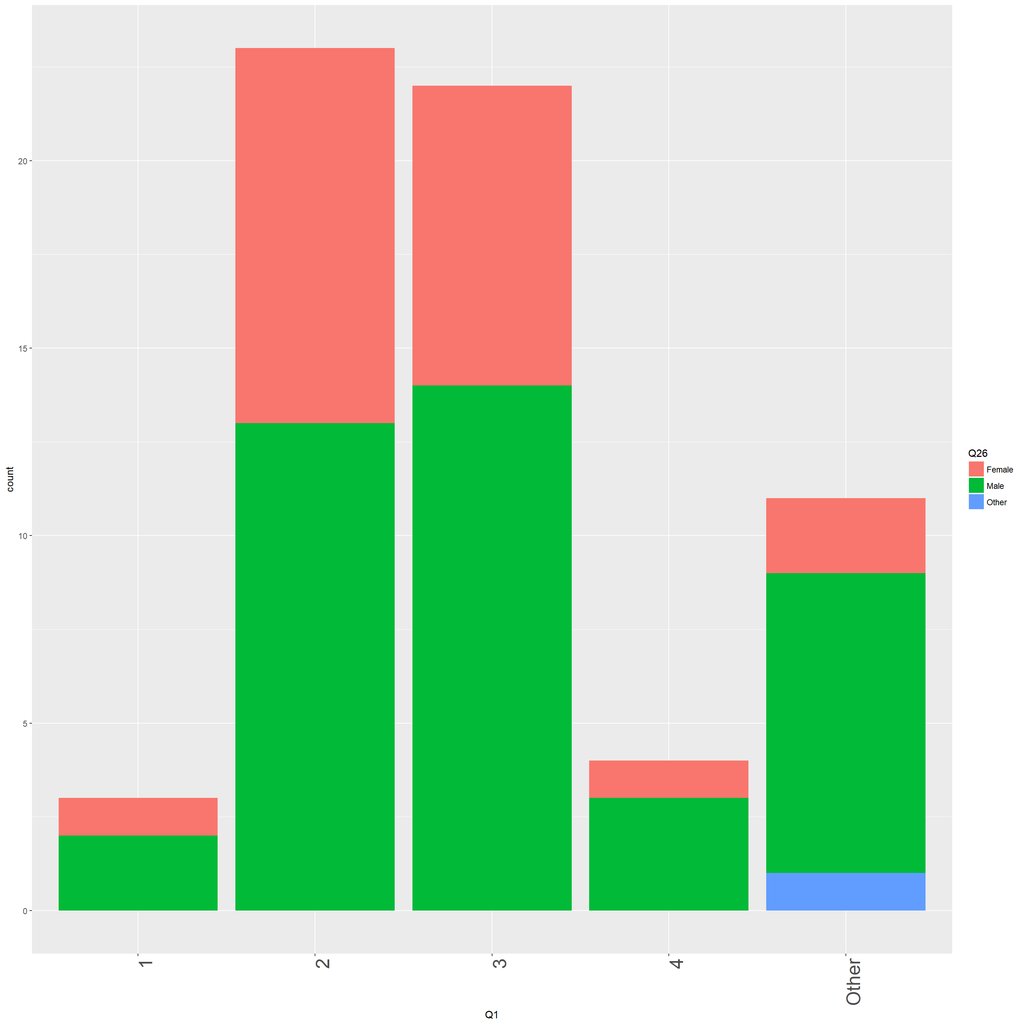

```r
ggplot(data = survey) +
  geom_bar(mapping = aes(x = Q1, fill= Q26), stat = "count") +
  theme(axis.text.x = element_text(angle = 90, hjust = 1, size = 20))
```

## People shirt size?

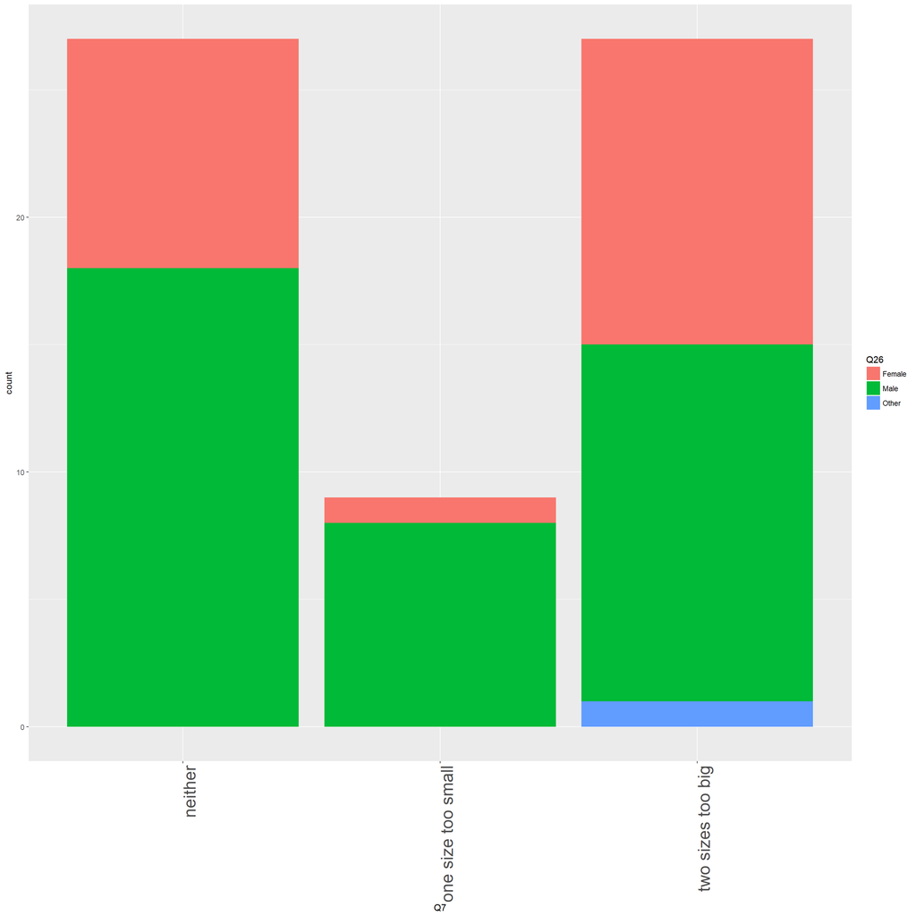

```r
ggplot(data = survey) +
  geom_bar(mapping = aes(x = Q7, fill=Q26), stat = "count") +
  theme(axis.text.x = element_text(angle = 90, hjust = 1, size = 20))
```

## How much time do people spend studying a week?

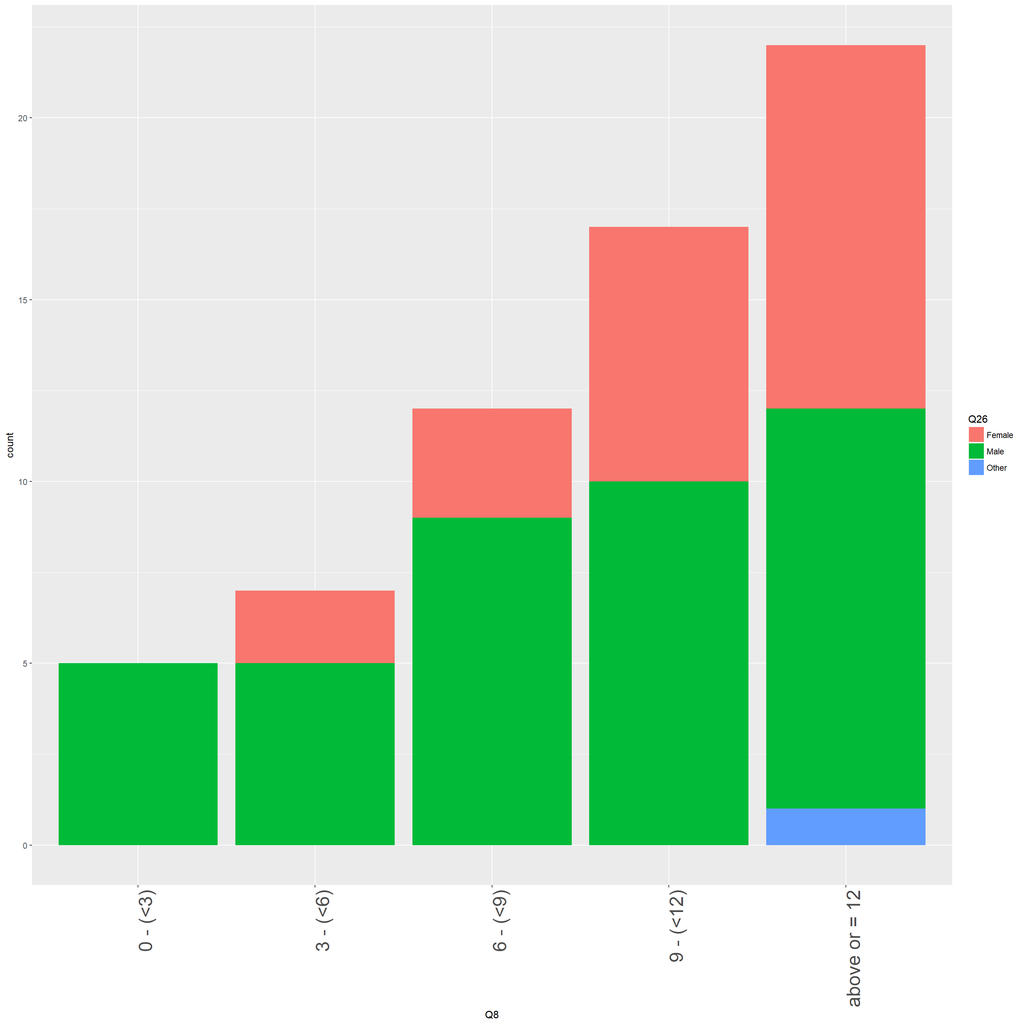

```r
ggplot(data = survey) +
  geom_bar(mapping = aes(x = Q8, fill= Q26), stat = "count") +
  theme(axis.text.x = element_text(angle = 90, hjust = 1, size = 20))
```

## IS this a core or an elective subject

#### it can be seen that this subject is mostly being taken as a core subject but it is not much greater then those taking it as an elective

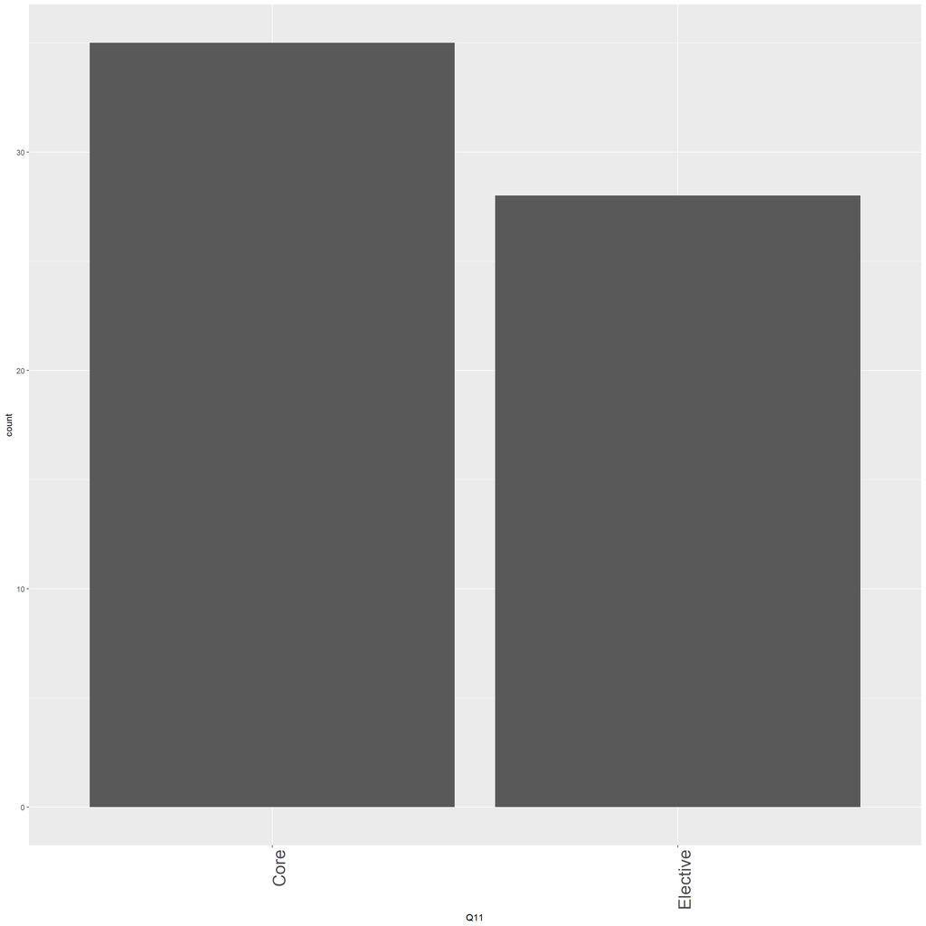

```r
ggplot(data = survey) + geom_bar(mapping = aes(x = Q11), stat = 'count') + theme(axis.text.x = element_text(angle = 90, hjust = 1, size = 20))
```

## Are you studing a single or a double degree?

#### it is similar mix between people studying both a single degree and a double degree.

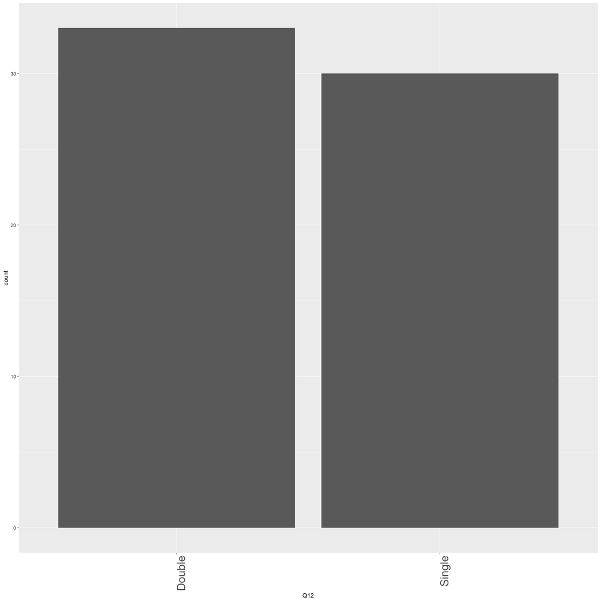

```r
ggplot(data = survey) + geom_bar(mapping = aes(x = Q12), stat = 'count') + theme(axis.text.x = element_text(angle = 90, hjust = 1, size = 20))
```

## do you like Carrots or cucumbers

#### more people like cucumbers more then they like carrots

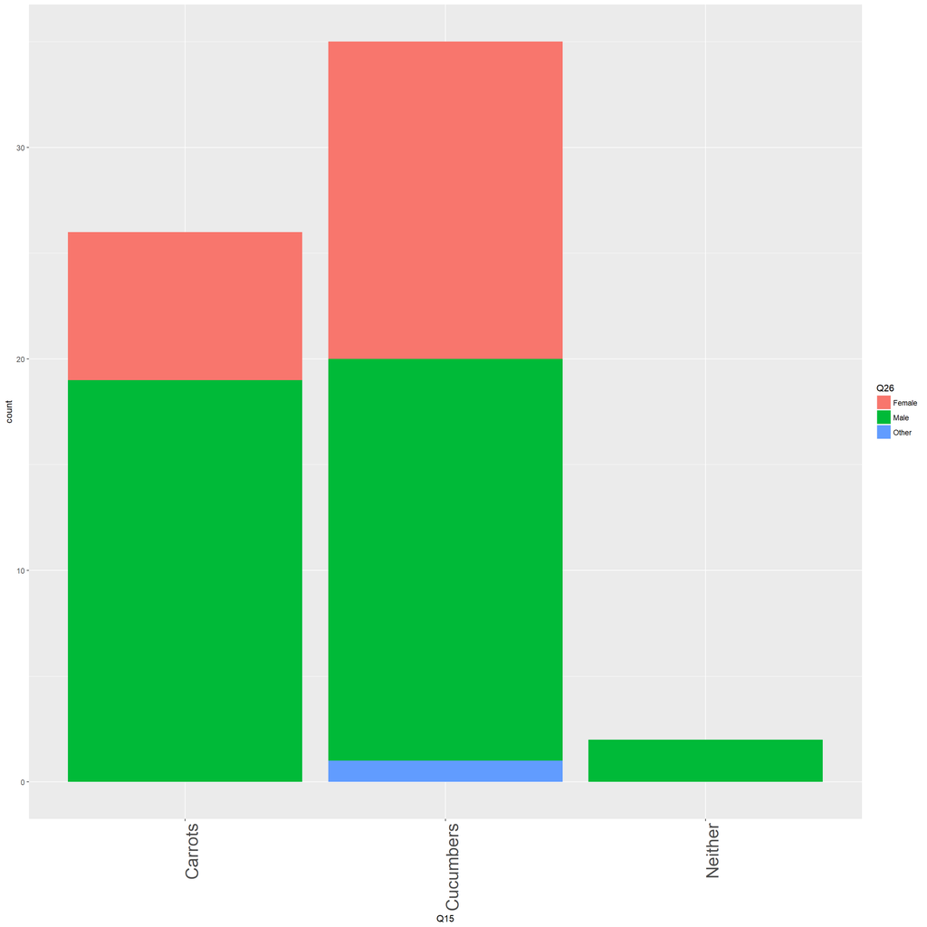

```r
ggplot(data = survey) + geom_bar(mapping = aes(x = Q15, fill=Q26), stat = 'count') + theme(axis.text.x = element_text(angle = 90, hjust = 1, size = 20))
```

## Do you have any Coding experience

#### females have an equal amount of coding and noncoding expererience where males have more coding experience overall.

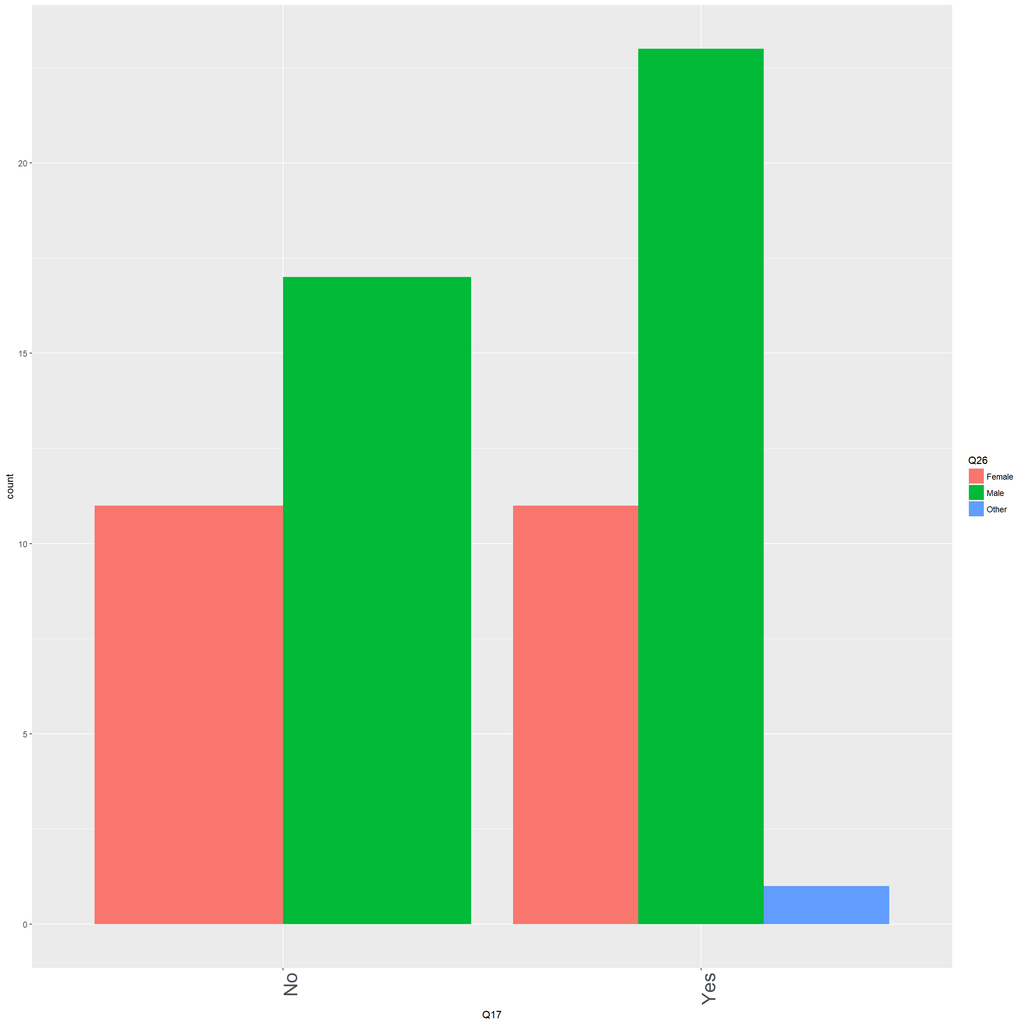

```r
ggplot(data = survey) +
  geom_bar(mapping = aes( x=Q17, fill=Q26), position = "dodge") +
  theme(axis.text.x = element_text(angle = 90, hjust = 1, size = 20))
```

## What operating System do you use?

#### can see that more people use a windows operating system

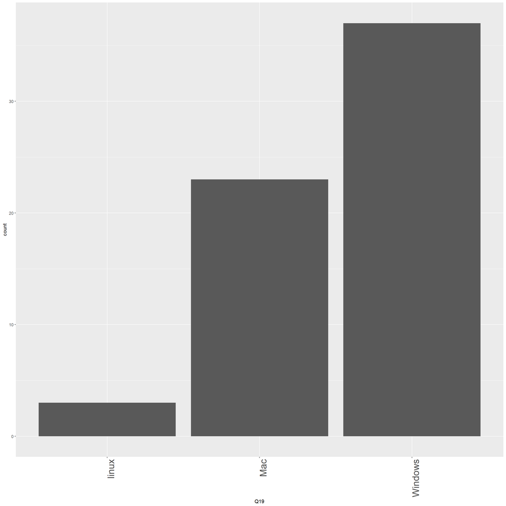

```r
ggplot(data = survey) + geom_bar(mapping = aes(x = Q19), stat = 'count') + theme(axis.text.x = element_text(angle = 90, hjust = 1, size = 20))
```

## support same sex marriage

#### more people support same sex marriage then not.

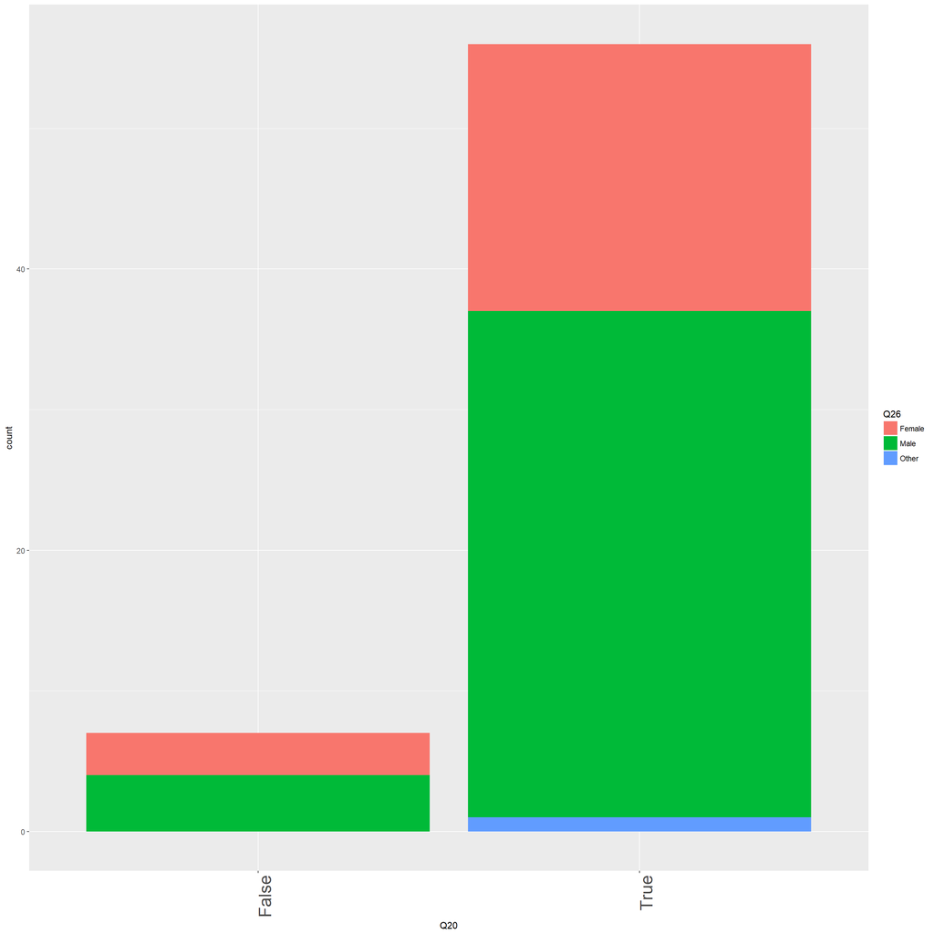

```r
ggplot(data = survey) + geom_bar(mapping = aes(x = Q20, fill=Q26), stat = 'count') + theme(axis.text.x = element_text(angle = 90, hjust = 1, size = 20))
```

## How many hours do you sleep average

#### most people average between 7-8 hours sleep a night

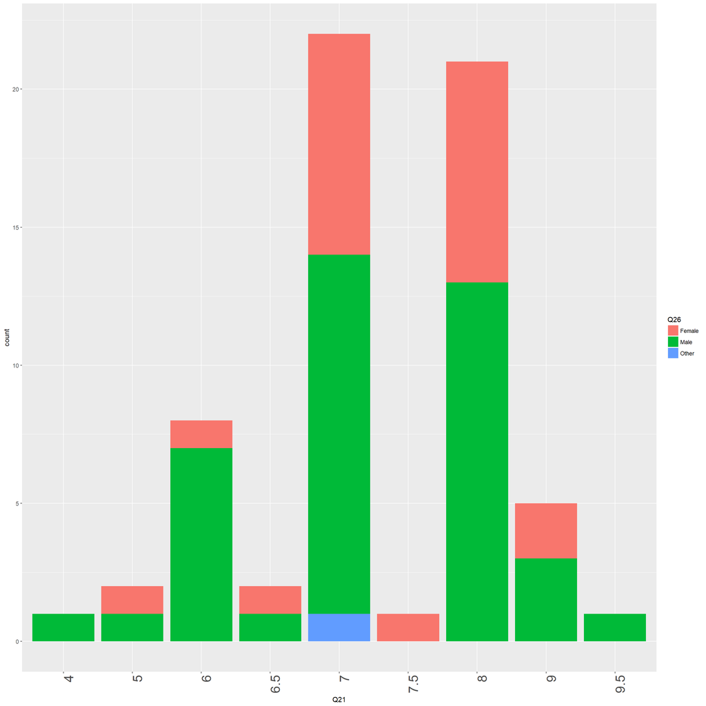

```r
ggplot(survey, aes(x=Q21, fill = Q26), position = "dodge") +
  geom_bar() +
  theme(axis.text.x = element_text(angle = 90, hjust = 1, size = 20))
```

## what is your age is years

#### majority of females is between 19-20 were the majority of males is 20-21

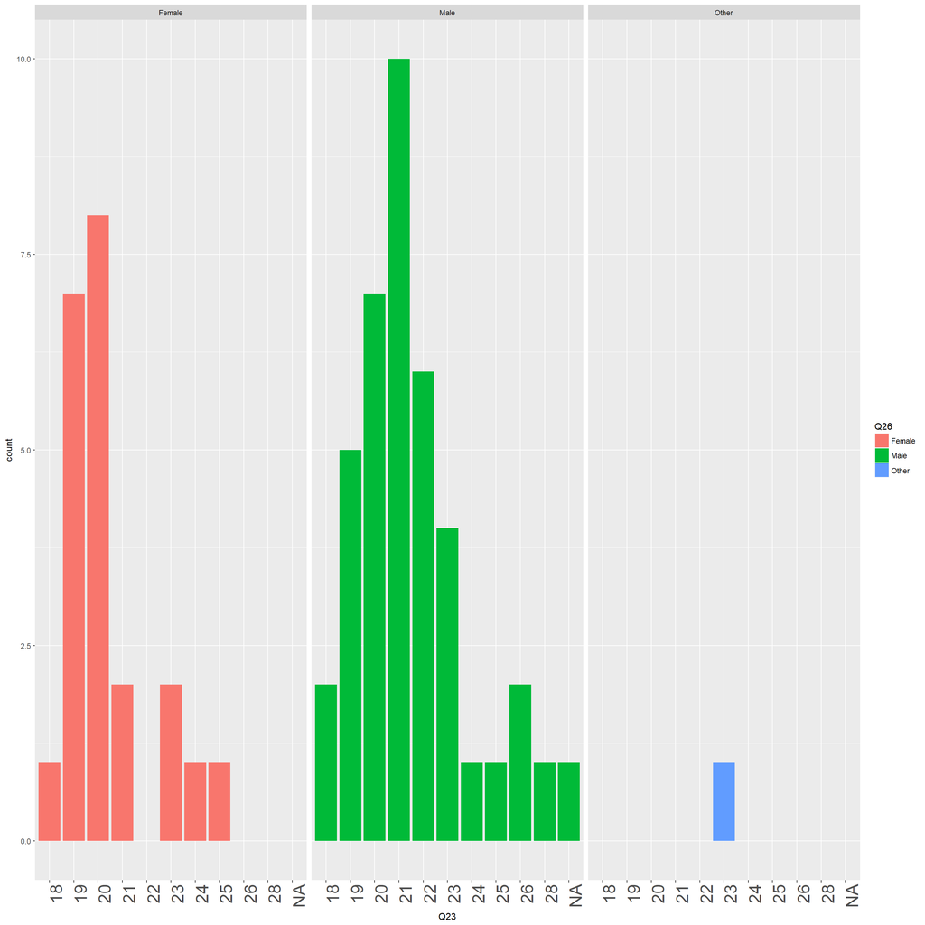

```r
ggplot(survey, aes(x = Q23, fill = Q26)) +
  geom_bar( position="dodge") +
  facet_grid(~ Q26) +
  theme(axis.text.x = element_text(angle = 90, hjust = 1, size = 20))
```

## How tall are you??

#### can be seen that the majority of males are taller then females

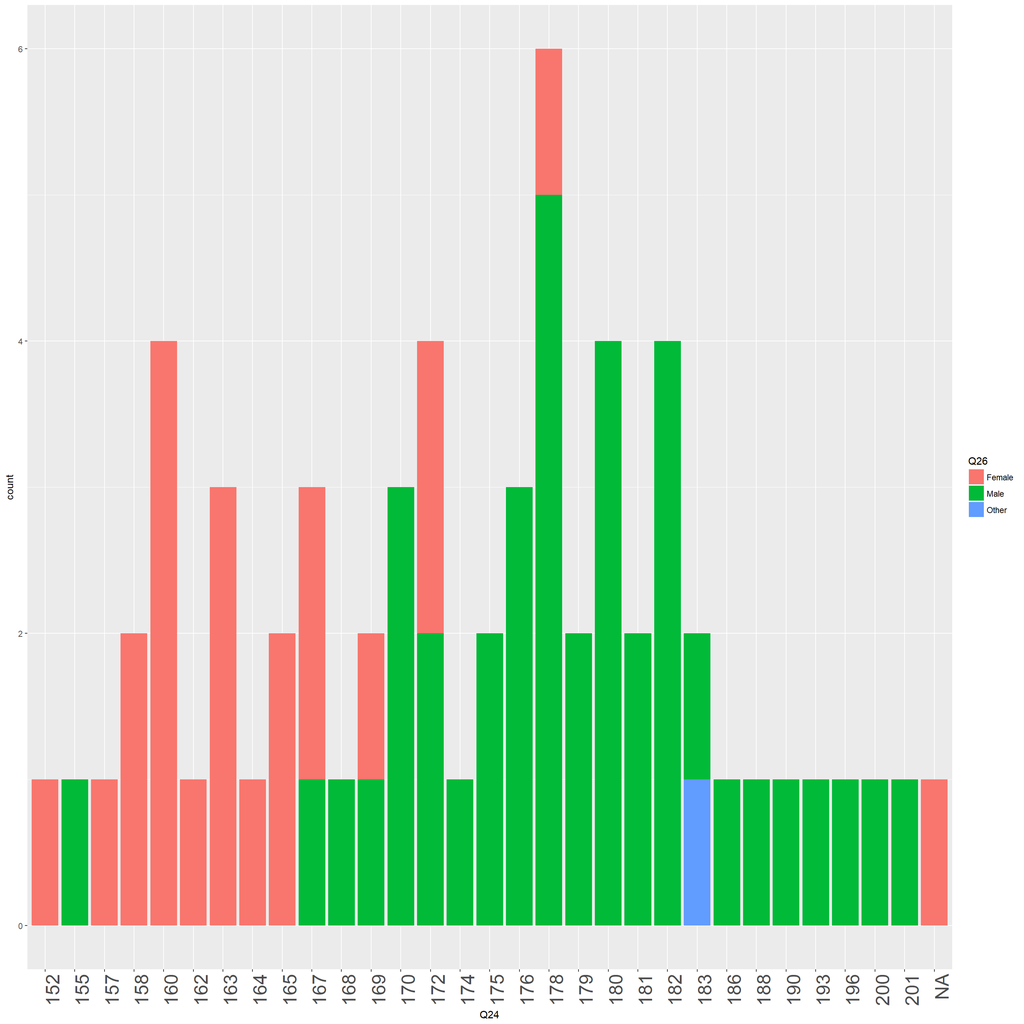

```r
ggplot(data = survey) + geom_bar(mapping = aes(x = Q24, fill=Q26), stat = 'count') + theme(axis.text.x = element_text(angle = 90, hjust = 1, size = 20))
```

## are you male or female?

#### there are more Males in this class then females

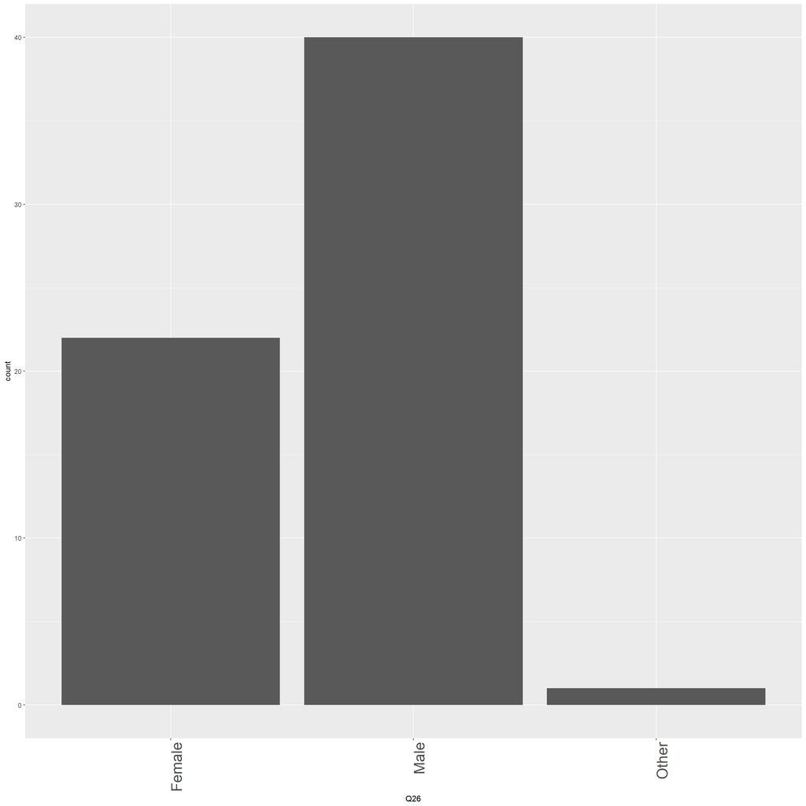

```r
ggplot(data = survey) + geom_bar(mapping = aes(x = Q26), stat = 'count') + theme(axis.text.x = element_text(angle = 90, hjust = 1, size = 20))
```

## do you put Tomato Sauce in the fridge or Pantry?

#### can be seen that more people put it in the fridge

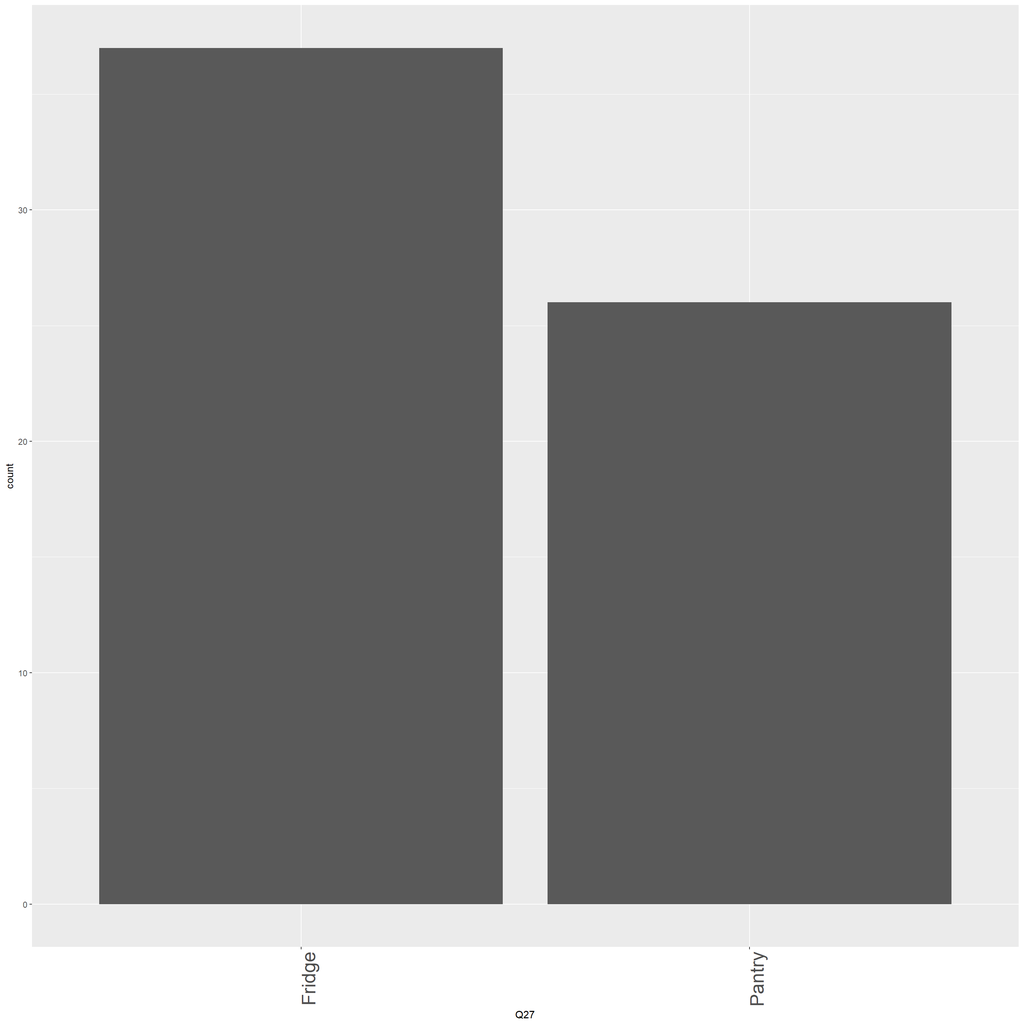

```r
ggplot(data = survey) + geom_bar(mapping = aes(x = Q27), stat = 'count') + theme(axis.text.x = element_text(angle = 90, hjust = 1, size = 20))
```

## How many books did you read last year

#### it can be seen a more guys read no books in a year where more girls read more then 20 books in a year

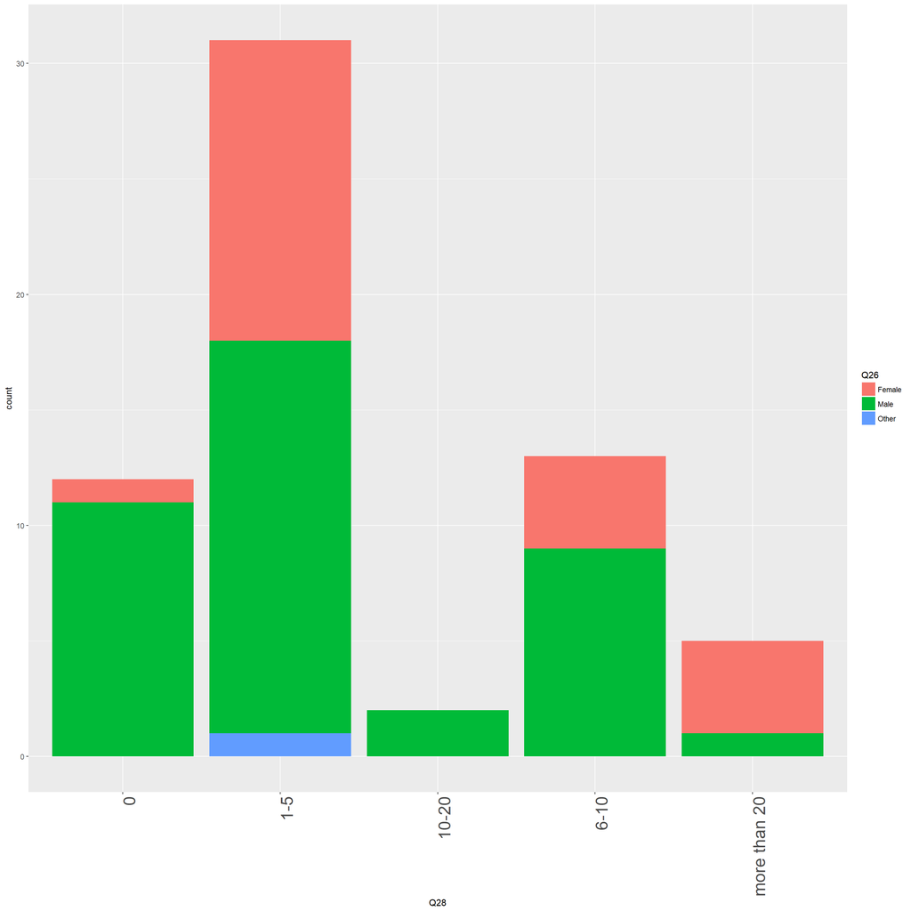

```r
ggplot(data = survey) + geom_bar(mapping = aes(x = Q28, fill=Q26), stat = 'count') + theme(axis.text.x = element_text(angle = 90, hjust = 1, size = 20))
```

## do you enjoy this unit?

#### more people with coding expereince enjoy this unit better then if they have no coding experience

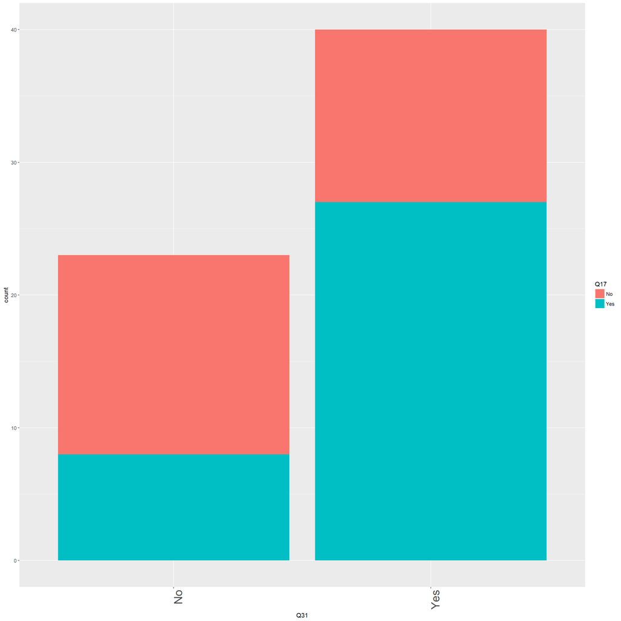

```r
ggplot(data = survey) + geom_bar(mapping = aes(x = Q31, fill =Q17), stat = 'count') + theme(axis.text.x = element_text(angle = 90, hjust = 1, size = 20))
```

## do you like cheese?

#### as a percentage of people who said false there is more guys then girls who dislike cheese

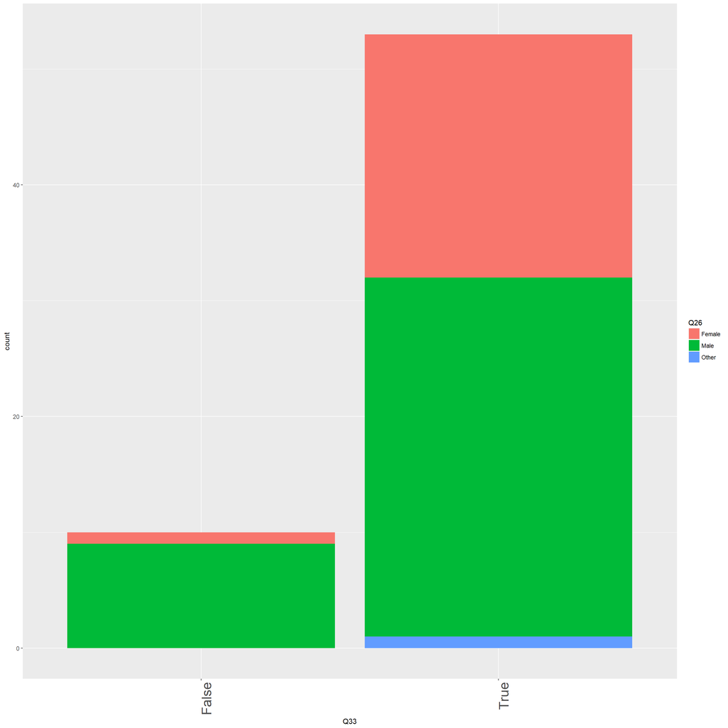

```r
ggplot(data = survey) + geom_bar(mapping = aes(x = Q33, fill=Q26), stat = 'count') + theme(axis.text.x = element_text(angle = 90, hjust = 1, size = 20))
```